# Chapter3_.1_Logistic Regression

This is an exercise sheet which goes through logistic regression.

```r
library(tidyverse)
library(ISLR)
library(MASS)
library(class)
```

1. Produce some numerical and graphical summaries of the Weekly data. Do there appear to be any patterns?

I’ll start with a summary of the data.

```r
summary(Weekly)
```

```
      Year           Lag1               Lag2
 Min.   :1990   Min.   :-18.1950   Min.   :-18.1950
 1st Qu.:1995   1st Qu.: -1.1540   1st Qu.: -1.1540
 Median :2000   Median :  0.2410   Median :  0.2410
 Mean   :2000   Mean   :  0.1506   Mean   :  0.1511
 3rd Qu.:2005   3rd Qu.:  1.4050   3rd Qu.:  1.4090
 Max.   :2010   Max.   : 12.0260   Max.   : 12.0260
      Lag3               Lag4
 Min.   :-18.1950   Min.   :-18.1950
 1st Qu.: -1.1580   1st Qu.: -1.1580
 Median :  0.2410   Median :  0.2380
 Mean   :  0.1472   Mean   :  0.1458
 3rd Qu.:  1.4090   3rd Qu.:  1.4090
 Max.   : 12.0260   Max.   : 12.0260
      Lag5              Volume
 Min.   :-18.1950   Min.   :0.08747
 1st Qu.: -1.1660   1st Qu.:0.33202
 Median :  0.2340   Median :1.00268
 Mean   :  0.1399   Mean   :1.57462
 3rd Qu.:  1.4050   3rd Qu.:2.05373
 Max.   : 12.0260   Max.   :9.32821
     Today          Direction
 Min.   :-18.1950   Down:484
 1st Qu.: -1.1540   Up  :605
 Median :  0.2410
 Mean   :  0.1499
 3rd Qu.:  1.4050
 Max.   : 12.0260
```

Okay, great. Next thing is to construct a matrix of scatterplots.

[figure not shown]

```r
pairs(Weekly)
```

The only intersting pattern is what looks like a logarithmic pattern at the intersection of `volume` and `year`.

2. Use the full data set to perform a logistic regression with Direction as the response and the five lag variables plus Volume as predictors. Use the summary function to print the results. Do any of the predictors appear to be statistically significant? If so, which ones?

```
Call:
glm(formula = Direction ~ Lag1 + Lag2 + Lag3 + Lag4 + Lag5 +
    Volume, family = "binomial", data = Weekly)

Deviance Residuals:
    Min       1Q   Median       3Q      Max
-1.6949  -1.2565   0.9913   1.0849   1.4579

Coefficients:
            Estimate Std. Error z value Pr(>|z|)
(Intercept)  0.26686    0.08593   3.106   0.0019 **
Lag1        -0.04127    0.02641  -1.563   0.1181
Lag2         0.05844    0.02686   2.175   0.0296 *
Lag3        -0.01606    0.02666  -0.602   0.5469
Lag4        -0.02779    0.02646  -1.050   0.2937
Lag5        -0.01447    0.02638  -0.549   0.5833
Volume      -0.02274    0.03690  -0.616   0.5377
---
Signif. codes:
0 ‘***’ 0.001 ‘**’ 0.01 ‘*’ 0.05 ‘.’ 0.1 ‘ ’ 1

(Dispersion parameter for binomial family taken to be 1)

    Null deviance: 1496.2  on 1088  degrees of freedom
Residual deviance: 1486.4  on 1082  degrees of freedom
AIC: 1500.4

Number of Fisher Scoring iterations: 4
```

It looks like the only statistically significant variable is `Lag2`. Indeed, the `p value` for some of these variables is quite large, indicating almost no relationship. It is notable that `Lag2` is the only variable which is positively correlated with the response variable `Direction`. This means that as `Direction` increases, so too does `Lag2`.

3. Compute the confusion matrix and overall fraction of correct predictions. Explain what the confusion matrix is telling you about the types of mistakes made by logistic regression.

A confusion matrix is a specific table layout that allows visualisation of the performance of an algorithm.

The first thing to do is to create a new object, here called `glm.probs`, to apply predictions to `model`.

```r
glm.probs <- predict(model, type = "response")
```

Next, we create a new object called `glm.preds` which contains the predictions, dependings on the value of the probability (here, set at greater than 50%). Next, construct a table which tells you how well the model predicted the responses.

```
      glm.preds
       Down  Up
  Down   54 430
  Up     48 557
```

In this case, the model predicted correctly 56.1% of the time. This is only slightly better than random chance, so my interpretation is that we need to refine the model or use a different function.

4. Now fit the logistic regression model using a training data period from 1990 to 2008, with Lag2 as the only predictor. Compute the confusion matrix and the overall fraction of correct predictions for the held out data (that is, the data from 2009 and 2010).

Begin by splitting into training (1990 to 2008) and test (2009 and 2010) sets.

```r
train <- Weekly %>% filter(Year <= 2008)
test <- Weekly %>% filter(Year > 2008)
```

Now, run the logistic regression model on the training set.

```r
model2 <- glm(data = train, Direction ~ Lag2, family="binomial")
summary(model2)
```

```
Call:
glm(formula = Direction ~ Lag2, family = "binomial", data = train)

Deviance Residuals:
   Min      1Q  Median      3Q     Max
-1.536  -1.264   1.021   1.091   1.368

Coefficients:
            Estimate Std. Error z value Pr(>|z|)
(Intercept)  0.20326    0.06428   3.162  0.00157 **
Lag2         0.05810    0.02870   2.024  0.04298 *
---
Signif. codes:  0 ‘***’ 0.001 ‘**’ 0.01 ‘*’ 0.05 ‘.’ 0.1 ‘ ’ 1

(Dispersion parameter for binomial family taken to be 1)

    Null deviance: 1354.7  on 984  degrees of freedom
Residual deviance: 1350.5  on 983  degrees of freedom
AIC: 1354.5

Number of Fisher Scoring iterations: 4
```

The model output indicates that there is a statistically significant relationship between `Lag2` and `Direction`. Again, however, we will use a prediction function to check the model accuracy. Note that we run the probabilities function on the test set, not the training set, and we assign it to ‘newdata’ within the function.

```
glm.preds2 Down Up
      Down    9  5
      Up     34 56
```

The overall number of correct predictions produced by this model is 62.5%.

5. Repeat (d) using LDA.

```r
model3 <- lda(Direction ~ Lag2, data = train)
model3
```

```
Call:
lda(Direction ~ Lag2, data = train)

Prior probabilities of groups:
     Down        Up
0.4477157 0.5522843

Group means:
            Lag2
Down -0.03568254
Up    0.26036581

Coefficients of linear discriminants:
           LD1
Lag2 0.4414162
```

The `group means` output is the average of each predictor in each class. Here, (given that `Lag2` is two days away from `Direction`, the group means show that there is a tendency for them to be Up by 0.26, 2 days after the market has been up, and down by 0.03, two days after the market has been Down.)

As shown above, the `lda` analysis identified 44% of days when the `Direction` was down and 55% of days when the `Direction` was up. Next, we use the `lda.predict` function to predict lda values.

```r
lda.predict <- predict(model3, newdata = test)
lda.class <- lda.predict$class
table(lda.class, test$Direction)
```

```
lda.class Down Up
     Down    9  5
     Up     34 56
```

The overall correct number of predictions produced by this model is 62.5%

6. Repeat (d) using QDA.

```r
model4 <- qda(data = train, Direction ~ Lag2)
model4
```

```
Call:
qda(Direction ~ Lag2, data = train)

Prior probabilities of groups:
     Down        Up
0.4477157 0.5522843

Group means:
            Lag2
Down -0.03568254
Up    0.26036581
```

Note that there are no coefficients for the `qda` model, because the QDA classifier involves a quadratic, rather than linear, function.

```r
qda.predict <- predict(model4, newdata = test)
table(qda.predict$class, test$Direction)
```

```
       Down Up
  Down    0  0
  Up     43 61
```

The accuracy of this model is 58.7%.

7. Repeat (d) using KNN with K =1.

```r
train <- train %>%
  dplyr::select(Lag2, Direction)
knn.pred = knn(train=data.frame(train$Lag2), test=data.frame(test$Lag2), cl=train$Direction, k=1)
cm.g <- table(test$Direction, knn.pred)
cm.g
```

```
      knn.pred
       Down Up
  Down   21 22
  Up     29 32
```

The accuracy of the knn model is 51%

8. Which of these methods appears to provide the best results on this data?

The best models are the logistic regression and the LDA, both at 62.5%

1. Experiment with different combinations of predictors, including possible transformations and interactions, for each of the methods. Report the variables, method, and associated confusion matrix that appears to provide the best results on the held out data. Note that you should also experiment with values for K in the KNN classifier.

I’ll just do the knn classifier for now. To do this, I’m going to steal some code from the internet.

```r
##First, I'll set the training and and test data
train <- Weekly %>% dplyr::filter(Year <= 2008)
test <- Weekly %>% dplyr::filter(Year > 2008)
results <- data.frame(k=1:50, acc=NA)
for(i in 1:50){
  knn.pred = knn(train=data.frame(train$Lag2), test=data.frame(test$Lag2), cl=train$Direction, k=i)
  cm <- table(test$Direction, knn.pred)
  acc <- (cm["Down", "Down"] + cm["Up", "Up"])/sum(cm)
  results$acc[i] <- acc
}
```

Once that function has run, I can now graph it to look how the model has been fit.

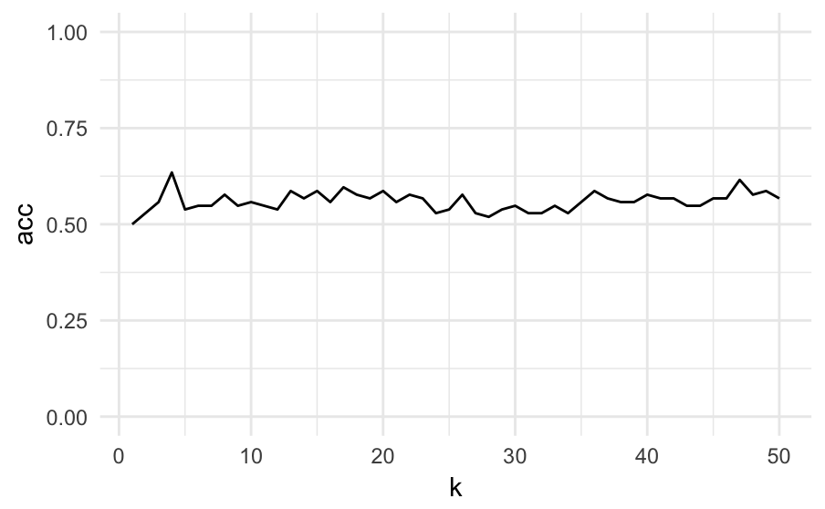

```r
ggplot(results, aes(k, acc)) +
  geom_line() +
  ylim(0:1) +
  theme_minimal()
```

| k | acc |
| --- | --- |
| 4 | 0.6346154 |
| 47 | 0.6153846 |
| 17 | 0.5961538 |
| 13 | 0.5865385 |
| 15 | 0.5865385 |
| 20 | 0.5865385 |
| 36 | 0.5865385 |
| 49 | 0.5865385 |
| 8 | 0.5769231 |
| 18 | 0.5769231 |

[output cut: 40 more lines]

As can be seen in the graph above, there doesn’t appear to be too much gain in accuracy of the model depending on the k value. The highest value is 4, with 63% accuracy.